# In-Class Session 10: Regression Discontinuity

Econometrics I

This notebook reproduces the simulations behind Lecture 10 and leaves you four short problems. The slides use `rdd_sims.R` (in this folder), which runs the same simulations with more plotting. Everything is simulated, so you always know the right answer. You need `rdrobust` and `rddensity` from CRAN.

# Part 1: The sharp design

## Reproduce: SOX Section 404 at the $75M threshold

Accelerated filers (public float of at least $75M) needed an auditor attestation of internal controls from fiscal 2004. The running variable is $x = \log(\text{float}/\$75\text{M})$, so the cutoff is $x = 0$. The outcome is the fiscal 2004 log audit fee. Without SOX, audit fees rise smoothly but non-linearly with size; `curv` scales the curvature. The true jump is $\tau = 0.35$. We also record fiscal 2002 fees, before SOX existed.

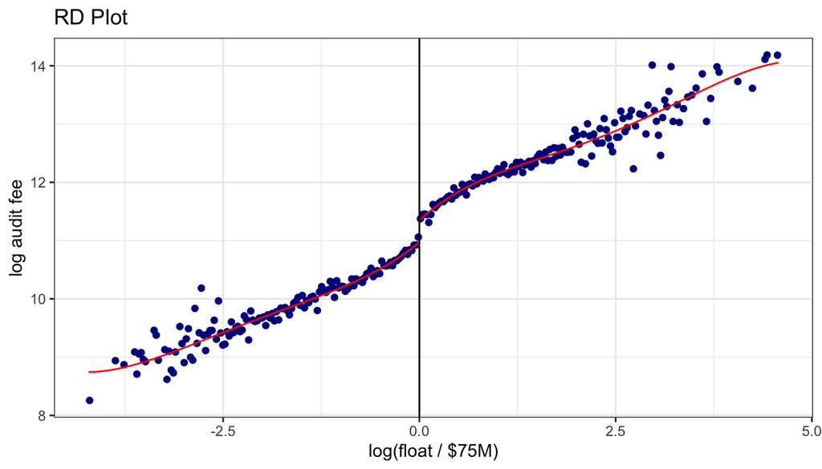

```r
tau <- 0.35
f0 <- function(x, curv = 1) 11 + 0.5 * x + curv * 0.3 * tanh(2.5 * x)
sim_sox <- function(N = 4000, curv = 1) {
  x <- rnorm(N, 0, 1.2)
  u <- rnorm(N, 0, 0.25)                        # persistent audit-cost shifter
  D <- as.integer(x >= 0)
  data.frame(x = x, u = u, D = D,
             y = f0(x, curv) + tau * D + u + rnorm(N, 0, 0.2),
             y_pre = f0(x, curv) - 0.06 + u + rnorm(N, 0, 0.2))
}
d <- sim_sox()
rdplot(d$y, d$x, c = 0, x.label = "log(float / $75M)", y.label = "log audit fee")
```

Global polynomials (separate on each side) against local linear regression:

```r
global_poly <- function(d, p) coef(feols(as.formula(sprintf("y ~ D * poly(x, %d, raw = TRUE)", p)), d))["D"]
sapply(1:5, function(p) global_poly(d, p))
```

```
##         D         D         D         D         D
## 0.6868297 0.5652048 0.4509012 0.3766493 0.3205729
```

```r
rd <- rdrobust(d$y, d$x, c = 0)
summary(rd)
```

```
## Call: rdrobust
##
## Sharp RD estimates using local polynomial regression.
##
## Number of Obs.                 4000
## BW type                       mserd
## Kernel                   Triangular
## VCE method                       NN
##
##                                Left        Right
## Number of Obs.                 2010         1990
## Eff. Number of Obs.             635          591
## Order est. (p)                    1            1
## Order bias (q)                    2            2
## BW est. (h)                   0.481        0.481
## BW bias (b)                   1.021        1.021
## rho (h/b)                     0.472        0.472
## Unique Obs.                    2010         1990
##
## =====================================================================
##                    Point    Robust Inference
##                 Estimate         z     P>|z|      [ 95% C.I. ]
## ---------------------------------------------------------------------
##      RD Effect     0.362     7.468     0.000     [0.253 , 0.433]
## =====================================================================
```

```r
h <- rd$bws["h", "left"]
s <- subset(d, abs(x) < h); s$k <- 1 - abs(s$x) / h
etable(feols(y ~ D * x, s, weights = ~k, vcov = "hetero"))   # coefficient on D = rdrobust's "Conventional"
```

```
##                 feols(y ~ D * x,..
## Dependent Var.:                  y
##
## Constant         10.99*** (0.0289)
## D               0.3619*** (0.0408)
## x                1.118*** (0.1166)
## D x x             -0.0719 (0.1675)
## _______________ __________________
## S.E. type       Heteroskedas.-rob.
## Observations                 1,226
## R2                         0.59002
## Adj. R2                    0.58901
## ---
## Signif. codes: 0 '***' 0.001 '**' 0.01 '*' 0.05 '.' 0.1 ' ' 1
```

### Problem 1

Re-simulate with `curv = 0`, so audit fees are linear in $x$ on each side. What happens to the global linear estimate, and to $h_{MSE}$? Explain both in terms of the bias-variance tradeoff. Then try `curv = 2`.

```r
# your code here
```

## Reproduce: coverage of conventional vs. robust bias-corrected CIs

```r
mc <- function(R = 200, N = 4000, curv = 1) {
  out <- t(replicate(R, {
    s <- sim_sox(N, curv); r <- rdrobust(s$y, s$x)
    c(conv = r$ci[1, 1] <= tau & tau <= r$ci[1, 2], robust = r$ci[3, 1] <= tau & tau <= r$ci[3, 2], h = r$bws[1, 1])
  }))
  colMeans(out)
}
mc()
```

```
##      conv    robust         h
## 0.8500000 0.9350000 0.4551244
```

### Problem 2

Rerun the Monte Carlo with `N = 1000`. What happens to $h_{MSE}$ and to the coverage of each interval? Is the conventional interval’s problem bigger or smaller in small samples, and why? (Hint: at $h_{MSE}$, how does the bias compare to the standard error?)

```r
# your code here
```

# Part 2: Manipulation

## Reproduce: float management

Firms whose true float is between $75M and $96M ($0 \le x < 0.25$) may push their reported float just under $75M to stay exempt. Firms with higher audit costs $u$ are more likely to do it; `sel` sets how strongly manipulation selects on $u$. Manipulators stay exempt but keep the audit fees of their true size and costs.

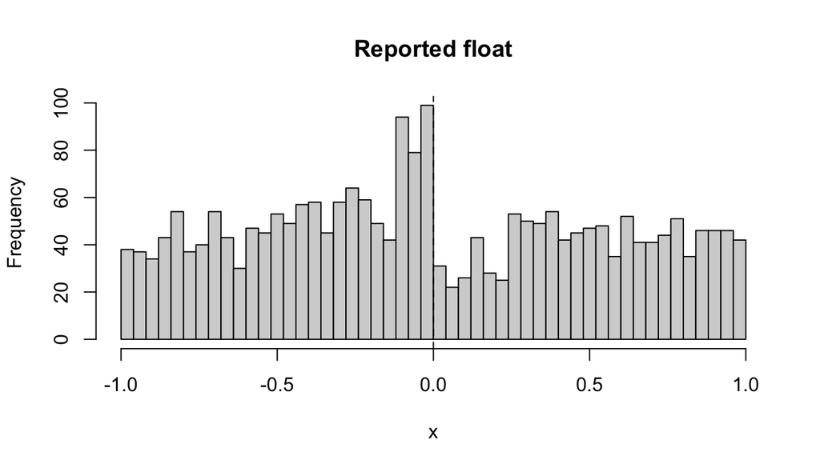

```r
manipulate <- function(d, sel = 8, base = -0.5) {
  cand <- which(d$x >= 0 & d$x < 0.25)
  m <- cand[runif(length(cand)) < plogis(base + sel * d$u[cand])]
  d$x[m] <- runif(length(m), -0.12, -0.005); d$D[m] <- 0L; d$y[m] <- d$y[m] - tau
  d
}
dm <- manipulate(d)
hist(dm$x[abs(dm$x) < 1], breaks = seq(-1, 1, by = 0.04), main = "Reported float", xlab = "x")
abline(v = 0, lty = 2)
```

```r
c(density_p = rddensity(dm$x)$test$p_jk,
  jump_2004 = rdrobust(dm$y, dm$x)$coef[1],
  jump_2002 = rdrobust(dm$y_pre, dm$x)$coef[1])
```

```
##     density_p     jump_2004     jump_2002
##  1.457225e-12  3.298388e-02 -3.648137e-01
```

### Problem 3

Set `sel = 0`, so manipulation is unrelated to audit costs. Which of the three numbers above still flags a problem, and which does not? Now vary `base` to change how many firms manipulate. Roughly how many manipulators does it take before the density test rejects at 5%? What does this tell you about relying on a single diagnostic?

```r
# your code here
```

# Part 3: Fuzzy RD

## Reproduce: voluntary compliers and extensions

Now crossing $75M only raises the probability of an attestation. Low-cost firms are more likely to attest on either side. `fs` sets how much crossing the cutoff matters.

```r
fuzzy <- function(d, fs = 2.4) {
  d$Z <- as.integer(d$x >= 0)
  d$D <- as.integer(-1.3 + fs * d$Z - 4 * d$u + rnorm(nrow(d)) > 0)
  d$y <- f0(d$x) + tau * d$D + d$u + rnorm(nrow(d), 0, 0.2)
  d
}
df <- fuzzy(d)
rf <- rdrobust(df$y, df$x, fuzzy = df$D)
h <- rf$bws["h", "left"]; s <- subset(df, abs(x) < h); s$k <- 1 - abs(s$x) / h
etable(feols(D ~ Z * x, s, weights = ~k, vcov = "hetero"),            # first stage
       feols(y ~ Z * x, s, weights = ~k, vcov = "hetero"),            # reduced form
       feols(y ~ x + Z:x | D ~ Z, s, weights = ~k, vcov = "hetero"))  # 2SLS = Wald ratio
```

```
##                 feols(D ~ Z * x,.. feols(y ~ Z * x,.. feols(y ~ x + Z:..
## Dependent Var.:                  D                  y                  y
##
## Constant        0.1758*** (0.0259)  11.03*** (0.0206)  10.94*** (0.0314)
## Z               0.5969*** (0.0396) 0.2888*** (0.0289)
## x                  0.0253 (0.0648) 0.9164*** (0.0510) 0.9041*** (0.0591)
## x x Z              0.0348 (0.0989)    0.0056 (0.0712)   -0.0112 (0.0849)
## D                                                     0.4838*** (0.0577)
## _______________ __________________ __________________ __________________
## S.E. type       Heteroskedas.-rob. Heteroskedas.-rob. Heteroskedas.-rob.
## Observations                 1,984              1,984              1,984
## R2                         0.38587            0.67805            0.36832
## Adj. R2                    0.38494            0.67756            0.36736
## ---
## Signif. codes: 0 '***' 0.001 '**' 0.01 '*' 0.05 '.' 0.1 ' ' 1
```

```r
summary(rf)
```

```
## Call: rdrobust
##
## Fuzzy RD estimates using local polynomial regression.
##
## Number of Obs.                 4000
## BW type                       mserd
## Kernel                   Triangular
## VCE method                       NN
##
##                                Left        Right
## Number of Obs.                 2010         1990
## Eff. Number of Obs.            1018          966
## Order est. (p)                    1            1
## Order bias (q)                    2            2
## BW est. (h)                   0.826        0.826
## BW bias (b)                   1.318        1.318
## rho (h/b)                     0.627        0.627
## Unique Obs.                    2010         1990
##
## First-stage estimates.
##
## =====================================================================
##                    Point    Robust Inference
##                 Estimate         z     P>|z|      [ 95% C.I. ]
## =====================================================================
##      Rd Effect     0.597    11.988     0.000     [0.487 , 0.678]
## =====================================================================
##
## Treatment effect estimates.
##
## =====================================================================
##                    Point    Robust Inference
##                 Estimate         z     P>|z|      [ 95% C.I. ]
## ---------------------------------------------------------------------
##      RD Effect     0.484     5.850     0.000     [0.269 , 0.540]
## =====================================================================
```

### Problem 4

First compare the conventional 2SLS interval above with the robust interval from `summary(rf)`. Which covers 0.35, and why? (Part 1 has the answer.) Then lower `fs` toward zero. Track the first-stage jump, the 2SLS estimate and its robust confidence interval from `rdrobust`. At what point does the estimate become unreliable? Connect this to weak instruments from Session 7.

```r
# your code here
```